# Práctica 2

## 4.2 Idea 4: hypothesis tests to check for differences in statistics for 5 positions

Let’s check the differences in some of the different stats for the five player positions. We will perform different statistical tests to check if the differences are significative or not.

### 4.2.1 Analysis planification

```r
## normality check for variables prior to application of this test
subset2 <- stats_with_salaries %>%
  select(c(Player, Tm, Pos, Age, WS, PPG, APG, MPG, Salary.in.. ))
  #select(c(Player, Tm, Pos, Age, TS., WS, PER, G, PPG, APG, RPG, BPG, SPG, MPG, Salary.in.. ))
```

We select the five analysis groups, i.e., the five types of players in the game:

```r
group.PG <- subset2 %>%  filter(Pos == 'PG')

head(group.PG)
```

|  | Player | Tm | Pos | Age | WS | PPG | APG | MPG | Salary.in.. |
| --- | --- | --- | --- | --- | --- | --- | --- | --- | --- |
| 1 | D.J. Augustin | ORL | PG | 29 | 1.2 | 7.897436 | 2.679487 | 19.71795 | 7250000 |
| 2 | Wade Baldwin | MEM | PG | 20 | -0.4 | 3.212121 | 1.848485 | 12.27273 | 1793760 |
| 3 | J.J. Barea | DAL | PG | 32 | 1.3 | 10.885714 | 5.514286 | 22.02857 | 4096950 |
| 4 | Jerryd Bayless | PHI | PG | 28 | -0.1 | 11.000000 | 4.333333 | 23.66667 | 9424084 |
| 5 | Eric Bledsoe | PHO | PG | 27 | 5.4 | 21.060606 | 6.333333 | 32.96970 | 14000000 |
| 6 | Aaron Brooks | IND | PG | 32 | 0.3 | 4.953846 | 1.923077 | 13.75385 | 2700000 |

```r
group.SG <- subset2 %>%  filter(Pos == 'SG')

head(group.SG)
```

|  | Player | Tm | Pos | Age | WS | PPG | APG | MPG | Salary.in.. |
| --- | --- | --- | --- | --- | --- | --- | --- | --- | --- |
| 1 | Alex Abrines | OKC | SG | 23 | 2.1 | 5.970588 | 0.5882353 | 15.51471 | 5994764 |
| 2 | Arron Afflalo | SAC | SG | 31 | 1.4 | 8.442623 | 1.2786885 | 25.90164 | 12500000 |
| 3 | Tony Allen | MEM | SG | 35 | 3.1 | 9.056338 | 1.3802817 | 26.95775 | 5505618 |
| 4 | Kyle Anderson | SAS | SG | 23 | 2.7 | 3.416667 | 1.2638889 | 14.16667 | 1192080 |
| 5 | Ron Baker | NYK | SG | 23 | -0.1 | 4.134615 | 2.0576923 | 16.48077 | 543471 |
| 6 | Leandro Barbosa | PHO | SG | 34 | 0.6 | 6.253731 | 1.2089552 | 14.37313 | 4000000 |

```r
group.SF <- subset2 %>%  filter(Pos == 'SF')

head(group.SF)
```

|  | Player | Tm | Pos | Age | WS | PPG | APG | MPG | Salary.in.. |
| --- | --- | --- | --- | --- | --- | --- | --- | --- | --- |
| 1 | Al-Farouq Aminu | POR | SF | 26 | 1.9 | 8.721311 | 1.6229508 | 29.06557 | 7680965 |
| 2 | Alan Anderson | LAC | SF | 34 | 0.1 | 2.866667 | 0.3666667 | 10.26667 | 1315448 |
| 3 | Justin Anderson | PHI | SF | 23 | 0.9 | 8.458333 | 1.4166667 | 21.58333 | 1514160 |
| 4 | Giannis Antetokounmpo | MIL | SF | 22 | 12.4 | 22.900000 | 5.4250000 | 35.56250 | 2995421 |
| 5 | Carmelo Anthony | NYK | SF | 32 | 4.7 | 22.418919 | 2.8783784 | 34.29730 | 24559380 |
| 6 | Trevor Ariza | HOU | SF | 31 | 6.0 | 11.700000 | 2.1875000 | 34.66250 | 7806971 |

```r
group.PF <- subset2 %>%  filter(Pos == 'PF')

head(group.PF)
```

|  | Player | Tm | Pos | Age | WS | PPG | APG | MPG | Salary.in.. |
| --- | --- | --- | --- | --- | --- | --- | --- | --- | --- |
| 1 | Quincy Acy | DAL | PF | 26 | -0.1 | 2.166667 | 0.0000000 | 8.00000 | 1050961 |
| 2 | Quincy Acy | BRK | PF | 26 | 1.1 | 6.531250 | 0.5625000 | 15.93750 | 1914544 |
| 3 | LaMarcus Aldridge | SAS | PF | 31 | 7.3 | 17.263889 | 1.9305556 | 32.43056 | 20575005 |
| 4 | Lavoy Allen | IND | PF | 27 | 1.7 | 2.901639 | 0.9344262 | 14.27869 | 4000000 |
| 5 | Ryan Anderson | HOU | PF | 28 | 5.2 | 13.597222 | 0.9444444 | 29.38889 | 18735364 |
| 6 | Darrell Arthur | DEN | PF | 28 | 1.1 | 6.390244 | 1.0243902 | 15.58537 | 8070175 |

```r
group.C <- subset2 %>%  filter(Pos == 'C')

head(group.C)
```

|  | Player | Tm | Pos | Age | WS | PPG | APG | MPG | Salary.in.. |
| --- | --- | --- | --- | --- | --- | --- | --- | --- | --- |
| 1 | Steven Adams | OKC | C | 23 | 6.4 | 11.312500 | 1.0750000 | 29.862500 | 3140517 |
| 2 | Alexis Ajinca | NOP | C | 28 | 1.0 | 5.307692 | 0.3076923 | 14.974359 | 4600000 |
| 3 | Cole Aldrich | MIN | C | 28 | 1.3 | 1.693548 | 0.4032258 | 8.564516 | 7643979 |
| 4 | Joel Anthony | SAS | C | 34 | 0.4 | 1.315789 | 0.1578947 | 6.421053 | 663810 |
| 5 | Omer Asik | NOP | C | 30 | 1.0 | 2.741935 | 0.4838710 | 15.548387 | 9904494 |
| 6 | Aron Baynes | DET | C | 30 | 3.0 | 4.866667 | 0.4266667 | 15.506667 | 6500000 |

We are going to study if there are any difference in the following variables, depending on the position of the player:

- Salary
- Points per Game
- Assists per Game
- Minutes per Game
- Win shares

First of all, we must check if each of these variables are normally distributed and there is homocedasticity. If the answer is affirmative, then an ANOVA test can be performed. If the answer is negative, we should perform a non-parametric test like the Kruskal-Wallis.

#### 4.2.1.1 Salary

```r
# normality test

shapiro.test(subset2$Salary.in..)
```

```
##
##  Shapiro-Wilk normality test
##
## data:  subset2$Salary.in..
## W = 0.81072, p-value < 2.2e-16
```

```r
# homocedasticity test
leveneTest(Salary.in..  ~ Pos, data = subset2)
```

|  | Df | F value | Pr(>F) |
| --- | --- | --- | --- |
| group | 4 | 0.6832988 | 0.6037939 |
|  | 464 | NA | NA |

```r
# normal--- we can do the anova test
test_salary <- kruskal.test(Salary.in..~ Pos, data= subset2)
#summary(anova)
```

There is no evidence that there exist a difference on the salary by the different position that a player has.

#### 4.2.1.2 PPG

```r
# normality test

shapiro.test(subset2$PPG)
```

```
##
##  Shapiro-Wilk normality test
##
## data:  subset2$PPG
## W = 0.89668, p-value < 2.2e-16
```

```r
# homocedasticity test

leveneTest(PPG  ~ Pos, data = subset2)
```

|  | Df | F value | Pr(>F) |
| --- | --- | --- | --- |
| group | 4 | 1.064615 | 0.3734622 |
|  | 464 | NA | NA |

```r
# normal--- we can do the anova test
test_PPG <-  kruskal.test(PPG~ Pos, data= subset2)

#summary(anova)
```

After running the test, no evidence was found that the PPG change significatively according to the player’s position on the field.

#### 4.2.1.3 APG

```r
# diferencias en APG

shapiro.test(subset2$APG)
```

```
##
##  Shapiro-Wilk normality test
##
## data:  subset2$APG
## W = 0.79879, p-value < 2.2e-16
```

```r
# homocedasticity test

leveneTest(APG  ~ Pos, data = subset2)
```

|  | Df | F value | Pr(>F) |
| --- | --- | --- | --- |
| group | 4 | 18.4717 | 4.25275e-14 |
|  | 464 | NA | NA |

```r
# normal--- we can do the anova test
test_APG <- aov(APG~ Pos, data= subset2)
summary(test_APG)
```

```
##              Df Sum Sq Mean Sq F value Pr(>F)
## Pos           4  397.8   99.45   42.44 <2e-16 ***
## Residuals   464 1087.3    2.34
## ---
## Signif. codes:  0 '***' 0.001 '**' 0.01 '*' 0.05 '.' 0.1 ' ' 1
```

```r
summary(test_APG)[[1]]$'Pr(>F)'[1]
```

```
## [1] 2.435007e-30
```

In this case, the Assists per Game depend on the position that the player has on the field. The p-value is really small (less than $10^{-16}$). Later, we will explore which of the possitions has a higher number of APG.

#### 4.2.1.4 MPG

```r
# normality test

shapiro.test(subset2$MPG)
```

```
##
##  Shapiro-Wilk normality test
##
## data:  subset2$MPG
## W = 0.97304, p-value = 1.324e-07
```

```r
# homocedasticity test
leveneTest(MPG  ~ Pos, data = subset2)
```

|  | Df | F value | Pr(>F) |
| --- | --- | --- | --- |
| group | 4 | 0.4066119 | 0.8039137 |
|  | 464 | NA | NA |

```r
# normal--- we can do the anova test
test_MPG <- kruskal.test(MPG~ Pos, data= subset2)
#summary(anova)
```

In the case of the MPG, we found that there is evidence to support the claim that the minutes played depend on the position. In this case, the p-value is still small (in the order of $10^{-3}$).

#### 4.2.1.5 WS

```r
# normality test

shapiro.test(subset2$WS)
```

```
##
##  Shapiro-Wilk normality test
##
## data:  subset2$WS
## W = 0.81405, p-value < 2.2e-16
```

```r
leveneTest(WS  ~ Pos, data = subset2)
```

|  | Df | F value | Pr(>F) |
| --- | --- | --- | --- |
| group | 4 | 3.309088 | 0.01089568 |
|  | 464 | NA | NA |

```r
# normal--- we can do the anova test
test_WS <- aov(WS~ Pos, data= subset2)
summary(test_WS)
```

```
##              Df Sum Sq Mean Sq F value  Pr(>F)
## Pos           4    114  28.465   3.408 0.00921 **
## Residuals   464   3875   8.352
## ---
## Signif. codes:  0 '***' 0.001 '**' 0.01 '*' 0.05 '.' 0.1 ' ' 1
```

Let us see a summary of the results of the analyses.

```r
DT = data.frame(
  Variable = c("Salary","PPG","APG","MPG","WS"),
  Result = c("No significative difference observed",
             "No significative difference observed",
             "Significative difference",
             "Significative difference",
             "Significative difference"),
  p.value = c(sprintf("%0.3f", test_salary$p.value),
            sprintf("%0.3f", test_PPG$p.value),
            sprintf("%0.2e", summary(test_APG)[[1]]$'Pr(>F)'[1]),
            sprintf("%0.2e", test_MPG$p.value),
            sprintf("%0.3f", summary(test_WS)[[1]]$'Pr(>F)'[1]))
)

DT
```

| Variable | Result | p.value |
| --- | --- | --- |
| Salary | No significative difference observed | 0.103 |
| PPG | No significative difference observed | 0.345 |
| APG | Significative difference | 2.44e-30 |
| MPG | Significative difference | 7.65e-03 |
| WS | Significative difference | 0.009 |

Now, let us check the source of the differences in the variables APG and MPG are coming from, i.e., which possitions have a higher value for those variables.

```r
# APG
summary(lm(APG ~ Pos, data = subset2))
```

```
##
## Call:
## lm(formula = APG ~ Pos, data = subset2)
##
## Residuals:
##     Min      1Q  Median      3Q     Max
## -3.1482 -0.9170 -0.3549  0.6379  7.5825
##
## Coefficients:
##             Estimate Std. Error t value Pr(>|t|)
## (Intercept)  1.09569    0.15959   6.865 2.13e-11 ***
## PosPF        0.09255    0.22825   0.405  0.68531
## PosPG        2.50704    0.22167  11.310  < 2e-16 ***
## PosSF        0.56473    0.23030   2.452  0.01457 *
## PosSG        0.67383    0.21860   3.082  0.00218 **
## ---
## Signif. codes:  0 '***' 0.001 '**' 0.01 '*' 0.05 '.' 0.1 ' ' 1
##
## Residual standard error: 1.531 on 464 degrees of freedom
## Multiple R-squared:  0.2679, Adjusted R-squared:  0.2615
## F-statistic: 42.44 on 4 and 464 DF,  p-value: < 2.2e-16
```

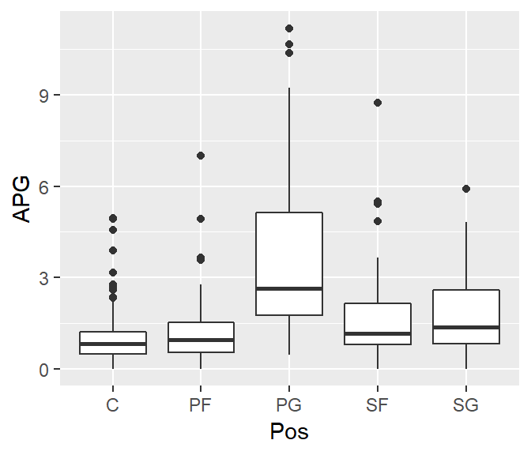

```r
subset2 %>%
  ggplot(aes(x = Pos , y = APG)) +
  geom_boxplot()
```

```r
pairwise.t.test(subset2$APG, subset2$Pos)
```

```
##
##  Pairwise comparisons using t tests with pooled SD
##
## data:  subset2$APG and subset2$Pos
##
##    C       PF      PG      SF
## PF 1.000   -       -       -
## PG < 2e-16 < 2e-16 -       -
## SF 0.058   0.129   1.1e-15 -
## SG 0.013   0.044   1.3e-15 1.000
##
## P value adjustment method: holm
```

Let us repeat the analysis for the MPG attribute.

```r
# MPG
summary(lm(MPG ~ Pos, data = subset2))
```

```
##
## Call:
## lm(formula = MPG ~ Pos, data = subset2)
##
## Residuals:
##      Min       1Q   Median       3Q      Max
## -17.8959  -6.7727  -0.4421   6.9765  18.5709
##
## Coefficients:
##             Estimate Std. Error t value Pr(>|t|)
## (Intercept)  18.3803     0.9067  20.271  < 2e-16 ***
## PosPF         0.9271     1.2968   0.715 0.475035
## PosPG         2.2422     1.2595   1.780 0.075681 .
## PosSF         4.6387     1.3085   3.545 0.000432 ***
## PosSG         2.7656     1.2420   2.227 0.026448 *
## ---
## Signif. codes:  0 '***' 0.001 '**' 0.01 '*' 0.05 '.' 0.1 ' ' 1
##
## Residual standard error: 8.697 on 464 degrees of freedom
## Multiple R-squared:  0.03101,    Adjusted R-squared:  0.02265
## F-statistic: 3.712 on 4 and 464 DF,  p-value: 0.005493
```

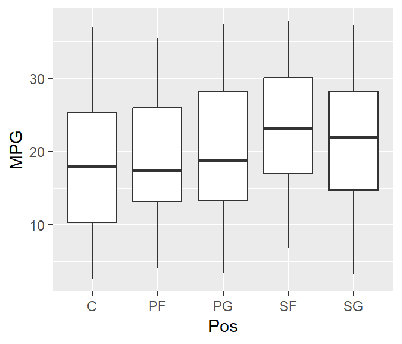

```r
subset2 %>%
  ggplot(aes(x = Pos, y = MPG)) +
  geom_boxplot()
```

**IDEA**: for each anova test, check where the differences are coming from, using the reference Dalgaard p 131.

## 4.3 Salary prediction model

We are going to use the following subset of variables to predict the salary:

```r
subset3 <- subset %>%
  select(-c(Tm, Player))

names(subset3)
```

```
##  [1] "Pos"         "Age"         "G"           "GS"          "MPG"
##  [6] "PPG"         "APG"         "RPG"         "BPG"         "SPG"
## [11] "TOPG"        "PFPG"        "WS"          "PER"         "VORP"
## [16] "X2P."        "X3P."        "FG."         "TS."         "USG."
## [21] "Salary.in.."
```

Let us create different models and compare their adjusted R-squared.

```r
# all variables
model1 <- lm(Salary.in.. ~ .,
             data=subset3)

summary(model1)
```

```
##
## Call:
## lm(formula = Salary.in.. ~ ., data = subset3)
##
## Residuals:
##       Min        1Q    Median        3Q       Max
## -11522379  -2537283   -287102   2510987  16497540
##
## Coefficients:
##             Estimate Std. Error t value Pr(>|t|)
## (Intercept) -3700675    3181663  -1.163 0.245402
## PosPF        -881931     765393  -1.152 0.249833
## PosPG       -3005998    1037316  -2.898 0.003943 **
## PosSF       -2011648     924789  -2.175 0.030137 *
## PosSG       -2635173     961622  -2.740 0.006384 **
## Age           403168      48388   8.332 9.95e-16 ***
## G              10859      13049   0.832 0.405734
## GS             40041      13226   3.027 0.002610 **
## MPG          -142218     114103  -1.246 0.213275
## PPG           807431     201991   3.997 7.50e-05 ***
## APG           705696     378200   1.866 0.062708 .
## RPG           719306     228368   3.150 0.001744 **
## BPG          -414566     646726  -0.641 0.521838
## SPG          1147922     943379   1.217 0.224318
## TOPG         -361199     972248  -0.372 0.710435
## PFPG        -1876593     492161  -3.813 0.000157 ***
## WS             75524     292422   0.258 0.796318
## PER          -165753     129563  -1.279 0.201448
## VORP         -582967     444824  -1.311 0.190684
## X2P.        -5850339    4627825  -1.264 0.206832
## X3P.         -144102    1826245  -0.079 0.937143
## FG.          6099856    6574182   0.928 0.353988
## TS.         -2616527    6659917  -0.393 0.694599
## USG.         -101227      90498  -1.119 0.263931
## ---
## Signif. codes:  0 '***' 0.001 '**' 0.01 '*' 0.05 '.' 0.1 ' ' 1
##
## Residual standard error: 4248000 on 445 degrees of freedom
## Multiple R-squared:  0.5937, Adjusted R-squared:  0.5727
## F-statistic: 28.27 on 23 and 445 DF,  p-value: < 2.2e-16
```

```r
model2 <- lm(Salary.in.. ~ APG + RPG + PPG + Age + BPG + MPG*PPG
             + Age*MPG,
             data=subset3)

#summary(model2)
```

```r
# remove 2 var. from model2
model3 <- lm(Salary.in.. ~ MPG +  RPG + Age + BPG + MPG*PPG + Age*MPG,
             data=subset3)

#summary(model3)
```

```r
model4 <- lm(Salary.in.. ~  Age*MPG + WS + TOPG + PFPG + GS,
             data=subset3)

#summary(model4)
```

```r
model5 <- lm(Salary.in.. ~  I(Age)^2 + I(PPG)^3+ Age*MPG + Pos + RPG + TS. + GS + APG*TOPG+ USG.,
             data=subset3)

#summary(model5)
```

```r
model6 <- lm(Salary.in.. ~  I(Age)^2 + I(PPG)^3+  I(PFPG)^2+ Age*MPG + Pos + I(RPG)^2 + TS. + I(GS)^2 + APG*TOPG+
               USG.*TOPG + VORP + WS, data=subset3)

#summary(model6)
```

```r
# #models.table <- matrix(c(1, summary(model1)$adj.r.squared, unclass(summary(model1)$fstatistic[1]),
#                          2, summary(model2)$adj.r.squared, summary(model2)$fstatistic[1],
#                         3, summary(model3)$adj.r.squared, summary(model3)$fstatistic[1],
#                         4, summary(model4)$adj.r.squared, summary(model4)$fstatistic[1],
#                         5, summary(model5)$adj.r.squared, summary(model5)$fstatistic[1],
#                         6, summary(model6)$adj.r.squared), summary(model6)$fstatistic[1],
#                        ncol = 3, byrow = TRUE)
#
# #colnames(models.table) <- c("Model", "Adj. R-squared", "F-statistic")
#
# #models.table
```

```r
models.table <- data.frame(c(1, 2, 3 ,4 ,5, 6),
                           c( summary(model1)$adj.r.squared, summary(model2)$adj.r.squared,
                              summary(model3)$adj.r.squared, summary(model4)$adj.r.squared,
                              summary(model5)$adj.r.squared, summary(model6)$adj.r.squared),
                           c(summary(model1)$fstatistic[1],
                            summary(model2)$fstatistic[1],
                            summary(model3)$fstatistic[1],
                            summary(model4)$fstatistic[1],
                            summary(model5)$fstatistic[1],
                            summary(model6)$fstatistic[1]))

names(models.table) <- c("Model", "Adj. R-squared", "F-statistic")

models.table
```

| Model | Adj. R-squared | F-statistic |
| --- | --- | --- |
| 1 | 0.5726652 | 28.26783 |
| 2 | 0.5957975 | 87.22942 |
| 3 | 0.5966328 | 99.89043 |
| 4 | 0.5566585 | 84.94565 |
| 5 | 0.6081355 | 49.41935 |
| 6 | 0.6220001 | 41.53135 |

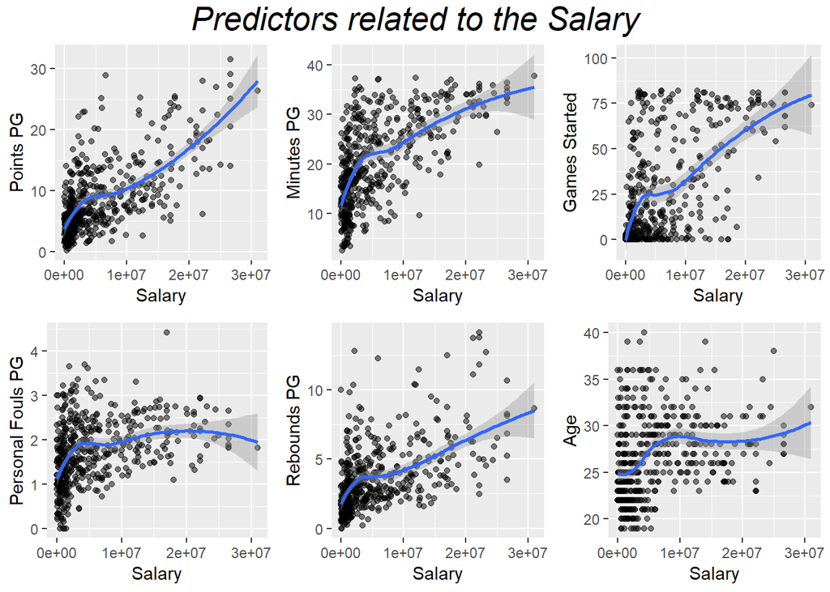

```r
# Salary vs PPG
p1 <- ggplot(subset, aes(x=Salary.in.., y=PPG)) +
  geom_point(alpha=0.5) + geom_smooth() +
  labs(x="Salary", y="Points PG") +
  theme(legend.position="none")

# Salary vs PPG
p2 <- ggplot(subset, aes(x=Salary.in.., y=MPG)) +
  geom_point(alpha=0.5) + geom_smooth() +
  labs(x="Salary", y="Minutes PG") +
  theme(legend.position="none")

# Salary vs PPG
p3 <- ggplot(subset, aes(x=Salary.in.., y=GS)) +
  geom_point(alpha=0.5) + geom_smooth() +
  labs(x="Salary", y="Games Started") +
  theme(legend.position="none")


# Salary vs PPG
p4 <- ggplot(subset, aes(x=Salary.in.., y=PFPG)) +
  geom_point(alpha=0.5) + geom_smooth() +
  labs(x="Salary", y="Personal Fouls PG") +
  theme(legend.position="none")

# Salary vs PPG
p5 <- ggplot(subset, aes(x=Salary.in.., y=RPG)) +
  geom_point(alpha=0.5) + geom_smooth() +
  labs(x="Salary", y= "Rebounds PG") +
  theme(legend.position="none")

# Salary vs PPG
p6 <- ggplot(subset, aes(x=Salary.in.., y=Age)) +
  geom_point(alpha=0.5) + geom_smooth() +
  labs(x="Salary", y="Age")

# Represent all the subplots
grid.arrange(p1, p2, p3, p4, p5, p6,
             layout_matrix=cbind(c(1,4), c(2,5), c(3,6)),
             top = textGrob("Predictors related to the Salary",
                            gp=gpar(fontsize=20,font=3)))
```

Let us now predict the salaries that some of the free agents of the 2016-2017 season would make in the season 2017-2018. We can check the list of free agents in this [link](https://www.hoopsrumors.com/2017/06/top-50-nba-free-agents-of-2017.html).

For the predictions, we will use the model named `model6`, as it was the one with the higher adjusted R squared.

```r
griffin <- subset %>% filter(Player == 'Blake Griffin')
# predicted salary
pred_griffin <- predict(model6, griffin)


curry <- subset %>% filter(Player == 'Stephen Curry')
# predicted salary
pred_curry <- predict(model6, curry)

lowry <- subset %>% filter(Player == 'Kyle Lowry')
# predicted salary
pred_lowry <- predict(model6, lowry)


hill <- subset %>% filter(Player == 'George Hill')
# predicted salary
pred_hill <- predict(model6, hill)

ibaka <- subset %>% filter(Player == 'Serge Ibaka')
# predicted salary
pred_ibaka <- predict(model6, ibaka)

p.gasol <- subset %>% filter(Player == 'Pau Gasol')
# predicted salary
pred_gasol <- predict(model6, p.gasol)


redick <- subset %>% filter(Player == 'J.J. Redick')
# predicted salary
pred_redick <- predict(model6, redick)

preds_model6 <- c(pred_griffin, pred_hill, pred_redick, pred_lowry, pred_gasol, pred_ibaka, pred_curry)
```

Now we can compare those predictions with the actual salaries those players got in that season.

```r
player_names <- c('Blake Griffin', 'Stephen Curry', 'Kyle Lowry',
             'George Hill', 'Serge Ibaka', 'Pau Gasol', 'J.J. Redick' )

# see the filtered players
subset %>% filter(Player %in% player_names)
```

| Player | Tm | Pos | Age | G | GS | MPG | PPG | APG | RPG | BPG | SPG | TOPG | PFPG | WS | PER | VORP | X2P. | X3P. | FG. | TS. | USG. | Salary.in.. |
| --- | --- | --- | --- | --- | --- | --- | --- | --- | --- | --- | --- | --- | --- | --- | --- | --- | --- | --- | --- | --- | --- | --- |
| Stephen Curry | GSW | PG | 28 | 79 | 79 | 33.39241 | 25.30380 | 6.6202532 | 4.468354 | 0.2151899 | 1.8101266 | 3.025316 | 2.316456 | 12.6 | 24.6 | 6.2 | 0.537 | 0.411 | 0.468 | 0.624 | 30.1 | 12112359 |
| Pau Gasol | SAS | C | 36 | 64 | 39 | 25.42188 | 12.37500 | 2.3437500 | 7.828125 | 1.0937500 | 0.3750000 | 1.265625 | 1.718750 | 6.4 | 20.2 | 2.4 | 0.494 | 0.538 | 0.502 | 0.578 | 21.3 | 15500000 |
| Blake Griffin | LAC | PF | 27 | 61 | 61 | 34.03279 | 21.57377 | 4.9180328 | 8.131148 | 0.3770492 | 0.9508197 | 2.327869 | 2.573770 | 7.7 | 22.7 | 3.4 | 0.514 | 0.336 | 0.493 | 0.569 | 28.0 | 20140838 |
| George Hill | UTA | PG | 30 | 49 | 49 | 31.51020 | 16.91837 | 4.1428571 | 3.408163 | 0.2244898 | 1.0204082 | 1.734694 | 2.326531 | 5.9 | 19.3 | 2.2 | 0.523 | 0.403 | 0.477 | 0.599 | 23.5 | 8000000 |
| Serge Ibaka | TOR | PF | 27 | 23 | 23 | 30.95652 | 14.21739 | 0.6521739 | 6.782609 | 1.4347826 | 0.3043478 | 1.695652 | 3.304348 | 1.3 | 13.8 | 0.0 | 0.494 | 0.398 | 0.459 | 0.556 | 20.9 | 12250000 |
| Kyle Lowry | TOR | PG | 30 | 60 | 60 | 37.40000 | 22.40000 | 6.9500000 | 4.800000 | 0.3166667 | 1.4666667 | 2.883333 | 2.833333 | 10.1 | 22.9 | 4.9 | 0.518 | 0.412 | 0.464 | 0.623 | 24.9 | 12000000 |
| J.J. Redick | LAC | SG | 32 | 78 | 78 | 28.17949 | 15.03846 | 1.4102564 | 2.192308 | 0.1666667 | 0.7051282 | 1.256410 | 1.602564 | 4.8 | 14.8 | 1.1 | 0.462 | 0.429 | 0.445 | 0.599 | 21.9 | 7377500 |

```r
# salaries in 2016-17
true_salaries <-
  salaries_2017 %>%
  filter(Player.Name %in% player_names) %>%
  select(Player.Name, Salary.in..)
names(true_salaries) <- c("Player", "salary_2017")

#predicted sal. for 2017-18 for these players
true_salaries$predicted_2018 <- preds_model6




# salaries they obtained in the 2017-18 season
true_salaries_2018 <-
  salaries %>%
  filter(Season.End==2018, Player.Name %in% player_names) %>%
  select(Player.Name, Salary.in..)
names(true_salaries_2018) <- c("Player", "true_salary_2018")



# see the differences
salaries_comparison <- full_join(true_salaries, true_salaries_2018, by =c('Player' = 'Player' ) )
salaries_comparison$pred_error <- salaries_comparison$true_salary_2018 - salaries_comparison$predicted_2018
salaries_comparison
```

| Player | salary_2017 | predicted_2018 | true_salary_2018 | pred_error |
| --- | --- | --- | --- | --- |
| Blake Griffin | 20140838 | 16232826 | 29512900 | 13280074 |
| George Hill | 8000000 | 12099458 | 20000000 | 7900542 |
| J.J. Redick | 7377500 | 14079457 | 23000000 | 8920543 |
| Kyle Lowry | 12000000 | 17190876 | 28703704 | 11512828 |
| Pau Gasol | 15500000 | 17251344 | 16000000 | -1251344 |
| Serge Ibaka | 12250000 | 8964770 | 20061729 | 11096959 |
| Stephen Curry | 12112359 | 16708167 | 34682550 | 17974383 |

We see that for Pau Gasol, the prediction error is less than 1.5 M$, but for the other players, the differences are unacceptable. It is intereseting, though, to see how the model detected a salary raise in the J.J. Redick and George Hill salaries for the 2017-18 season, though the raise was shorter than in the real life.

We can show the predictions made by the different models, to see if the model with the highest adjusted R-squared was the one that made the best predictions. Let us check `model1`, which uses all variables and `model3`, the one with the higher F-statistic of all the six models.

```r
# model 1
pred_griffin_model1 <- predict(model1, griffin)

pred_curry_model1 <- predict(model1, curry)

pred_lowry_model1 <- predict(model1, lowry)

pred_hill_model1 <- predict(model1, hill)

pred_ibaka_model1 <- predict(model1, ibaka)

pred_gasol_model1 <- predict(model1, p.gasol)

pred_redick_model1 <- predict(model1, redick)

preds_model1 <-  c(pred_griffin_model1, pred_hill_model1, pred_redick_model1,
                  pred_lowry_model1, pred_gasol_model1, pred_ibaka_model1,
                  pred_curry_model1)

# model 3
pred_griffin_model3 <- predict(model3, griffin)

pred_curry_model3 <- predict(model3, curry)

pred_lowry_model3 <- predict(model3, lowry)

pred_hill_model3 <- predict(model3, hill)

pred_ibaka_model3 <- predict(model3, ibaka)

pred_gasol_model3 <- predict(model3, p.gasol)

pred_redick_model3 <- predict(model3, redick)

preds_model3 <- c(pred_griffin_model3, pred_hill_model3, pred_redick_model3,
                  pred_lowry_model3, pred_gasol_model3, pred_ibaka_model3,
                  pred_curry_model3)
```

```r
true_salaries$predicted_model1 <-  preds_model1


true_salaries$predicted_model3 <-  preds_model3


# see the differences
salaries_comparison <- full_join(true_salaries, true_salaries_2018, by =c('Player' = 'Player' ) )
salaries_comparison
```

| Player | salary_2017 | predicted_2018 | predicted_model1 | predicted_model3 | true_salary_2018 |
| --- | --- | --- | --- | --- | --- |
| Blake Griffin | 20140838 | 16232826 | 17036348 | 17506777 | 29512900 |
| George Hill | 8000000 | 12099458 | 10332166 | 13877478 | 20000000 |
| J.J. Redick | 7377500 | 14079457 | 11955640 | 12390258 | 23000000 |
| Kyle Lowry | 12000000 | 17190876 | 14461343 | 20688659 | 28703704 |
| Pau Gasol | 15500000 | 17251344 | 15187828 | 15972730 | 16000000 |
| Serge Ibaka | 12250000 | 8964770 | 6923571 | 11045350 | 20061729 |
| Stephen Curry | 12112359 | 16708167 | 16954000 | 17793142 | 34682550 |

```r
# library(effects)
#
# plot(predictorEffects(lm(Salary.in.. ~ MPG + PPG + Age , data=subset3)))
```

Some ideas to improve the model would be the following:

- Change the model from regression to other ones that are able to detect the nature of the salaries. Let us notice that the best adjusted R-squared obtained was around 0.6, which is not a great value.
- There are other considerations in the salary predictions that were not considered. For example, **the salary cap available for a season** (that is, the limit of money that every team can spend on salaries) or the **player’s eligibility for a super-max contract**. In the case of Steph Curry, he was eligible for a super-max extension, thus, he earned a lot more money than predicted.
- If a player enters free-agency from a rookie contract, he is expected to earn more money the next season. This wasn’t considered in this model.

### 4.3.1 Analysis planification

Selección de los grupos de datos que se quieren analizar/comparar

### 4.3.2 Normality and homogeneity check for the variance

Comprobación de la normalidad y homogeneidad de la varianza

### 4.3.3 Statistical tests

Aplicación de pruebas estadísticas para comparar los grupos de datos. En función de los datos y el objetivo del estudio, aplicar pruebas de contraste de hipótesis, correlaciones, regresiones, etc. Aplicar al menos tres métodos de análisis diferentes.

# 5 miscelaneous

```r
## evolution of points scored though the years------------------------

# group points by year

points_by_year <- season_stats %>% group_by(Year) %>% summarise(total = sum(PTS))

str(points_by_year)
```

```
## Classes 'tbl_df', 'tbl' and 'data.frame':    69 obs. of  2 variables:
##  $ Year : int  1950 1951 1952 1953 1954 1955 1956 1957 1958 1959 ...
##  $ total: int  103562 65338 58096 64356 55252 55253 59768 59654 63093 67031 ...
```

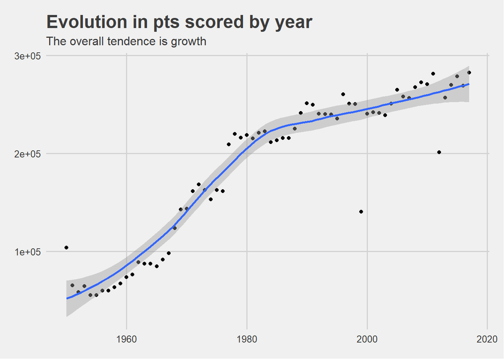

```r
# plot; geom_smooth options: method = "lm", se = FALSE

points_by_year %>% ggplot(aes(Year, total)) +
  geom_point()+ geom_smooth()+
  #geom_bar(stat = "identity") +
  theme_fivethirtyeight(base_size = 12, base_family = "sans") +
  ggtitle('Evolution in pts scored by year') +
  labs(subtitle = "The overall tendence is growth")
```

```r
### averaged salaries grouped by teams -----------
library(tidyverse)
n_seasons_salaries <- n_distinct(salaries$Season.Start)
salaries_by_team <- salaries %>% group_by(Team) %>%
  summarise(total = sum(Salary.in..), avg = sum(Salary.in..)/n_seasons_salaries) %>%
  arrange(desc(avg))

str(salaries_by_team)
```

```
## Classes 'tbl_df', 'tbl' and 'data.frame':    30 obs. of  3 variables:
##  $ Team : Factor w/ 30 levels "ATL","BOS","CHA",..: 20 13 25 5 18 6 30 22 21 16 ...
##  $ total: num  1.72e+09 1.67e+09 1.63e+09 1.55e+09 1.54e+09 ...
##  $ avg  : num  61477303 59635473 58301938 55238422 54934016 ...
```

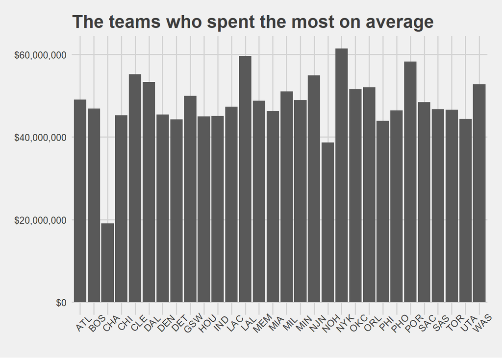

```r
# plot
library(ggthemes)
salaries_by_team %>% ggplot(aes(Team, avg)) +
  #geom_bar()+ geom_smooth(method = "lm", se = FALSE)+
  geom_bar(stat = "identity") +
  theme_fivethirtyeight(base_size = 12, base_family = "sans") +
  ggtitle('The teams who spent the most on average') +
  theme(axis.text.x = element_text(angle = 45)) +
  scale_y_continuous(labels = scales::dollar,
                     limits=c(0, max(salaries_by_team$avg)))
```

# 6 Representation of the results through tables and plots

(eliminar este apartado??)

# 7 Conclusions